# act_report

```python
import pandas as pd
import matplotlib.pyplot as plt
import seaborn as sns
```

```python
tweet_dog_ratings = pd.read_csv('pl1_tweet_dog_ratings.csv')
```

## Data Wrangling - We Rate Dogs on Twitter

### Introduction

The wrangling act or analysis carried out is based on a Twitter account called "We Rate Dogs". The user in this account rates dogs in very interesting and hilarious ways. The data for the sake of this analysis had to be gotten from three sources; twitter-archive-enhanced.csv, image-predictions.tsv and tweet-json.txt. All three dataset contain 2356 tweets of 5000 between November 2015 and August 2017.

### Wrangling effort

The data was "Gathered" both manually and programmatically from three sources namely; "twitter_achive_enhanced,csv", "image_predictions.tsv", and tweet-json.txt. After gathering, "Assessing" of the data was conducted both manually and programmatically to check for the data's quality and tidiness. Upon assessment, some quality issues like "missing values", "incorrect values", "inaccurate data type for some columns", and a lot more were discovered. Also, a major tidiness or structural issue found was that the data gathered ought to have been from a single source instead of three. The next step taken after discovery these issues was "Cleaning" the data using various methods and functions. A detailed explanation on all the steps taken in this wrangling act is documented in a separate file called "wrangle_report".

### Insights Gotten after Analysis and Visualization

Some insights were gotten after analysis and visualization was carried out. These insights are noted below:

1. iPhone was the major source of dog images.
2. Most dogs were rated between 9-13.
3. Retweet count and Favorite count have strong positive linear relationships.

### iPhone is the major source of dog images

```
[Text(0.5, 1.0, 'Most common Source')]
```

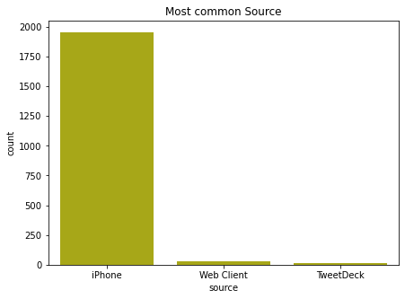

```python
plt.figure(figsize= (7,5))
sns.countplot(data= tweet_dog_ratings, x= 'source', color = 'y').set(title = 'Most common Source')
```

The use of iPhones is seen to be the major source of dog images as over 1800 pictures of dogs were gotten from iPhones making over more than 90%-95% of the total images received. The other sources making less than 10% of images received.